# Climatologies at high resolution for the earth’s land surface areas | Scientific Data

# Climatologies at high resolution for the earth’s land surface areas

- [Dirk Nikolaus Karger](https://www.nature.com/articles/sdata2017122)<sup>,</sup>,
- [Olaf Conrad](https://www.nature.com/articles/sdata2017122),
- [Jürgen Böhner](https://www.nature.com/articles/sdata2017122),
- [Tobias Kawohl](https://www.nature.com/articles/sdata2017122),
- [Holger Kreft](https://www.nature.com/articles/sdata2017122) ,
- [Rodrigo Wilber Soria-Auza](https://www.nature.com/articles/sdata2017122)<sup>,</sup>,
- [Niklaus E. Zimmermann](https://www.nature.com/articles/sdata2017122),
- [H. Peter Linder](https://www.nature.com/articles/sdata2017122) &
- [Michael Kessler](https://www.nature.com/articles/sdata2017122)

[*Scientific Data*](https://www.nature.com/sdata) **volume 4**, Article number: 170122 (2017) Cite this article

## Abstract

High-resolution information on climatic conditions is essential to many applications in environmental and ecological sciences. Here we present the CHELSA (Climatologies at high resolution for the earth’s land surface areas) data of downscaled model output temperature and precipitation estimates of the ERA-Interim climatic reanalysis to a high resolution of 30 arc sec. The temperature algorithm is based on statistical downscaling of atmospheric temperatures. The precipitation algorithm incorporates orographic predictors including wind fields, valley exposition, and boundary layer height, with a subsequent bias correction. The resulting data consist of a monthly temperature and precipitation climatology for the years 1979–2013. We compare the data derived from the CHELSA algorithm with other standard gridded products and station data from the Global Historical Climate Network. We compare the performance of the new climatologies in species distribution modelling and show that we can increase the accuracy of species range predictions. We further show that CHELSA climatological data has a similar accuracy as other products for temperature, but that its predictions of precipitation patterns are better.

| Design Type(s) | data integration objective • modeling and simulation objective |
| --- | --- |
| Measurement Type(s) | temperature of air • hydrological precipitation process |
| Technology Type(s) | data acquisition system |
| Factor Type(s) |  |
| Sample Characteristic(s) | Earth • planetary atmosphere |

Machine-accessible metadata file describing the reported data (ISA-Tab format)

## Background & Summary

High-resolution climate data are essential to many applications in environmental and ecological sciences. Whereas many studies in these fields are conducted at a resolution of ~1 km<sup>2</sup>, state-of-the-art global climate reanalyses often only represent climatic variation at spatial resolutions of 0.25°–1° (ca. 25–100 km at the equator). The gap between these spatial scales may be bridged using satellite data (CHIRPS<sup>1</sup>, TRMM<sup>2,3</sup>) and statistical downscaling<sup>4–7</sup> for a specific region of interest and/or interpolation methods applied to meteorological station data (WorldClim<sup>8</sup>, CRU<sup>9</sup>, GPCC<sup>10</sup>, PRISM<sup>11</sup>). Climatologies based on satellites or statistical downscaling, considered superior to interpolated data<sup>12</sup> for ecological applications, are currently either not available on a global scale or are still too coarse to reflect the small scale patterns needed in ecological studies. While interpolated datasets<sup>8</sup> often perform well in matching precipitation or temperature of the stations from which they are produced, they often fail to accurately predict patterns between stations. This is particularly problematic in highly variable terrain with low station density<sup>13</sup>. Whereas some interpolated datasets use elevation as a predictor (e.g., WorldClim<sup>8</sup>) and observations such as the Global Historical Climate Network (GHCN)<sup>14,15</sup> to achieve a high-resolution prediction, it is also possible to use predictors from global circulation models (e.g., from the National Center for Atmospheric Research (NCEP)<sup>16</sup>, or the European Centre for Medium-Range Weather Forecast (ECMWF) climatic reanalysis interim (ERA-Interim)<sup>17</sup>).

Although interpolation and statistical downscaling approaches may also integrate land-surface predictors such as elevation, slope or aspect, satisfactory results still require a more or less regular distribution of meteorological stations and a proper representation of topo-climatic settings<sup>13</sup>. However, the global distribution of meteorological stations is highly biased by funding and accessibility, leading to a poor representation of climatic variability in mountainous regions or areas with intact lowland rainforest, such as the Amazon or Congo basin<sup>8,13</sup>. On a global scale, it is also difficult to find generally valid transfer functions between predictors and the climatic variable of interests, especially for highly non-linear phenomena such as precipitation. Statistical downscaling is problematic<sup>18</sup>, especially on a global scale, due to temporal variation in the spatial distribution of weather stations. Although measurements for a given predictor might be available in a given month, they might be absent in another, leading to a generally high heterogeneity of the underlying climate records when time series of precipitation need to be calculated. While this does not affect static predictors such as elevation, slope, or aspect, statistical downscaling becomes especially problematic when highly dynamic predictors such as wind fields need to be integrated. The heterogeneity in the temporal and spatial distribution of such dynamic factors can also lead to spurious correlations in specific months or in specific regions, which can severely influence regression model parameters. When specific predictors, such as windward or leeward mountain sides<sup>19,20</sup> change over the course of the year, the location of the climatic records does not change accordingly. Therefore, regression-based downscaling might, for example, detect a significant negative relationship between a station on the windward site of a mountain for one month, and a positive relationship for another, although atmospheric physics would always predict a positive relationship. Due to this problem, statistical downscaling and interpolation methods have often been applied to single regions<sup>11</sup>, while a global model is lacking.

For ecological applications, the representation of the temporal and spatial variability of temperature and precipitation is, however, extremely important to infer ecological niches, growing seasons, species migrations, or small scale species distribution. Errors in the underlying climatic dataset at this small spatial scale can easily inflate in such studies<sup>13</sup>, which calls for an improvement of climatic information available for such analyses.

To overcome the problem of heterogeneous spatial and temporal distribution of meteorological station data, we use a Model Output Statistics algorithm for data provided from the ERA-Interim reanalysis<sup>17</sup> which we correct using gauge-derived products from the GPCC<sup>10</sup> and the GHCN<sup>14,15</sup> datasets. The results are improved climatologies for precipitation and temperature at high spatial resolution for environmental and ecological studies, which might prove valuable in varied scientific applications that rely on a good representation of small scale precipitation and temperature patterns.

## Methods

### Calculation of monthly temperature and precipitation values

ERA-Interim (developed at the European Centre for Medium-Range Weather Forecast, ECMWF), simulates six-hourly large-scale atmospheric fields for 60 pressure levels between 1,000 and 1 hPa globally with a horizontal resolution of 0.75° lat/long (T255)<sup>17,21,22</sup>. Since the ERA-Interim reanalysis combines modelling results with ground and radiosonde observations as well as remote sensing data using a data assimilation system, the free-atmospheric and surface fields can be considered as the best approximation of the current large-scale atmospheric situation for every time step. Several studies show that ERA-Interim adequately captures the variability of relevant free-air meteorological parameters, even over complex terrain<sup>23–25</sup>.

### Temperature

Spatial variation in temperature is to a large degree determined by the vertical state of the troposphere and thus, if not affected by inversion layers, temperature decreases with increasing altitude<sup>26,27</sup>. The long term mean hypsometric temperature gradient covered in the ERA-Interim data accurately reflects the vertical distribution of moist- or dry-adiabatic lapse rates<sup>20</sup>. Typical temperature lapse rates are in the order of −0.4 to −0.8 K/100 m with a characteristic seasonality. The corresponding temperature distribution pattern in the free atmosphere<sup>28</sup> can be assumed to be directly related to surface elevation<sup>19</sup>.

### Precipitation

Elevation is one of the main topo-climatic drivers of vertical precipitation gradients, but the relation between elevation and precipitation can be idiosyncratic<sup>19,31–36</sup>. In the convective regimes of the tropics, precipitation amounts commonly increase up to the condensation level at about 1,000–1,500 m above the ground surface, and the exponentially decreasing air moisture content in the mid- to upper troposphere results in a corresponding drying above the condensation level of tropical convection cluster systems (non-linear precipitation lapse rates)<sup>37</sup>. Likewise, negative lapse rates typically occur in the extremely dry polar climates. At mid-latitudes and in the subtropics, the frequent or even prevalent advection of moisture bearing air to high altitudes leads to increasing precipitation with increasing elevation. Consequently, the summits of high mountain ranges such as the Alps<sup>38</sup> may have high rainfall, and this leads to linear precipitation lapse rates<sup>39</sup>. The reduced precipitation at lower elevations is due, firstly, to the evaporation of rain drops when falling through non-saturated, lower-air levels. Secondly, the vertical precipitation gradient in high mountain ranges is often increased due to the diurnal formation of autochthonous upslope breezes. This upward flow of air intensifies cloud and precipitation formation in upper slope positions whilst the subsiding branch of these autochthonous local circulation systems along the valley axis leads to cloud dissolution and a corresponding reduction of precipitation rates in the valley bottoms. We approximated such orographic precipitation effects and used them as a parameter for the CHELSA precipitation downscaling algorithm (Fig. 1) as explained below.

**Figure 1: Workflow of the CHELSA model output statistics and interpolation algorithm for precipitation data.**

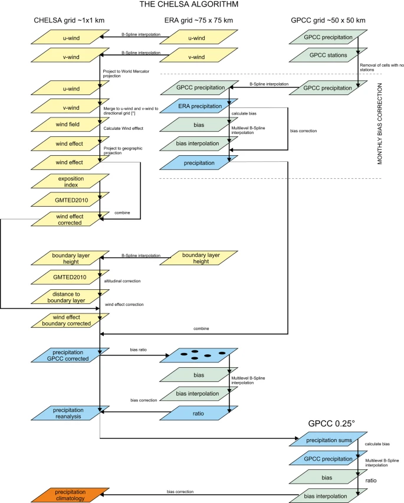

Resulting raster datasets (parallelograms) from each calculation step (arrows) are shown for each step of the algorithm. Predictor variables are indicated in yellow, raster datasets of the dependent variable (precipitation) are indicated in blue, and bias correction raster datasets are indicated in green. The final climatological product is indicated in orange.

[Full size image](https://www.nature.com/articles/sdata2017122/figures/1)

### Wind effect correction

Orographic precipitation patterns<sup>40</sup> caused by the uplift of moist air currents at the windward side of a mountain range and the intimately related rain shadow effect on leeward sides induced by the blockage of moisture-bearing air are most common effects influencing small-scale precipitation patterns<sup>38,40–43</sup>. Based on the assumption that the windward impact on the precipitation intensity depends on the prevailing wind direction at any given elevation of an orographic barrier, we used a wind index<sup>19,20</sup> to account for the expected higher precipitation at the windward sites of an orographic barrier.

### Boundary layer correction

with:

with:

### Precipitation data from ERA-Interim

For accumulated parameters (total monthly precipitation), we used the monthly means of daily forecast accumulations of total precipitation initialized at the synoptic hours 0:00 and 12:00. To calculate monthly precipitation sums, we added the synoptic monthly means at time 0:00, step 12 and time 12:00, step 12 and multiplied it by the number of days in the respective month.

### Station bias correction

We used precipitation from a set of meteorological stations from GHCN, MeteoSwiss, and DWD to correct the remaining error between *p* and *p*<sub>Station</sub>. We calculated the bias ratio between *p* and *p*<sub>*Station*</sub> and interpolated the bias ratio using a multilevel B-spline interpolation with 14 error levels to a 0.1° grid which matches the spatial accuracy of many GHCN stations. The resulting bias surface was then multiplied with *p* to achieve the final monthly precipitation estimates.

### Climatologies

We calculated the climatologies as the mean monthly sum of precipitation in the years 1979–2013 for each month. As slight errors in the precipitation sums can, however, accumulate over time, we applied an additional bias correction step using the GPCC Climatology Version 2015<sup>50</sup>. We used the cells at which stations are present, calculated the bias between the annual accumulations and the GPCC climatology, and used a multilevel B-spline interpolation of the biases to a 0.25 grid to create the bias surface. This bias surface was then multiplied with the mean annual precipitation sums to create the final climatologies.

### Bioclimatic parameters

*p*=monthly precipitation [mm]

Not listed here are the variables which are based on quarters (3 consecutive months) or specific (wettest, driest, warmest, coldest) months.

### Code availability

The codes used to calculate CHELSA climatologies are written in C++ and are included in SAGA Version 2.2.7, freely available at [www.saga-gis.org](http://www.saga-gis.org/) under the GNU public license including the necessary source codes. Calculations were done in SAGA Version 2.2.7 on the ‘Science Cloud’ cloud computing facility of the University of Zurich [www.s3it.uzh.ch/infrastructure/sciencecloud/](http://www.s3it.uzh.ch/Cinfrastructure/Csciencecloud/).

## Data Records

The CHELSA data contains records for monthly mean temperature in °C and precipitation values in mm/month, and derived bioclimatic variables for the reference period 1979–2013 in form of GeoTIFF files. The climatologies available for download have been derived from monthly values of precipitation and temperature. The files are freely available at [www.chelsa-climate.org](http://www.chelsa-climate.org/) as well as Dryad (Data Citation 1).

The file format is GeoTIFF.

Naming convention:

CHELSA_<variable><z-scale>_<month>_<Version>_land.tif

variable: prec=precipitation [mm/month]

temp=monthly mean of daily mean temperature [°C*10]

tmax=monthly mean of daily maximum temperature [°C*10]

tmin=monthly mean of daily minimum temperature [°C*10]

CHELSA_bio<z-scale>_<bioclim-variable>_<Version>_land.tif

bioclim-variable: 1=Annual Mean Temperature [°C*10]

2=Mean Diurnal Range [°C]

3=Isothermality

4=Temperature Seasonality [standard deviation]

5=Max Temperature of Warmest Month [°C*10]

6=Min Temperature of Coldest Month [°C*10]

7=Temperature Annual Range [°C*10]

8=Mean Temperature of Wettest Quarter [°C*10]

9=Mean Temperature of Driest Quarter [°C*10]

10=Mean Temperature of Warmest Quarter [°C*10]

11=Mean Temperature of Coldest Quarter [°C*10]

12=Annual Precipitation [mm/year]

13=Precipitation of Wettest Month [mm/month]

14=Precipitation of Driest Month [mm/month]

15=Precipitation Seasonality [coefficient of variation]

16=Precipitation of Wettest Quarter [mm/quarter]

17=Precipitation of Driest Quarter [mm/quarter]

18=Precipitation of Warmest Quarter [mm/quarter]

19=Precipitation of Coldest Quarter [mm/quarter]

## Technical Validation

To validate the results of the CHELSA algorithm and the different bias correction steps applied, we use a statistical cross-validation, compared the results with several comparable products that are available at comparable spatial and temporal resolution, and independent meteorological station data. The climatologies are validated in two steps. First, as the effects of orographic winds are a non-stationary phenomenon, we show a validation of the time series (hereafter: reanalysis) from which the climatologies are created. Second, we show a validation of the final climatological products which are available for download.

### Cross-validation of the bias correction method using monthly stations

To validate the results of the bias correction method using meteorological station data, we employed a cross-validation approach based on repeated split-resampling. We randomly omitted 20% of the stations for validation and used the remaining 80% for the bias correction by multilevel B-spline interpolation. We repeated the randomization 20 times per month for each respective year from 1979–2013. The mean R<sup>2</sup> values after cross-validation ranged between 0.53 and 0.90 with a mean of R<sup>2</sup>=0.77 and a root mean squared error (RMSE) ranging from 30.06–189.12 mm (mean=54.69 mm) globally throughout the years. A small increase in variance throughout the years can be observed, which might be due to the decrease in the number of stations throughout the years from 13,680 (Jan. 1979) to 1951 (Dec. 2013).

### Validation of the orographic precipitation patterns

[Full size table](https://www.nature.com/articles/sdata2017122/tables/2)

### Small-scale fit between stations and final climatology

Among the models which use GHCN in their algorithm, CHELSA shows the highest fit between stations and predicted precipitation, with WorldClim, GPCC and CRU showing smaller, but still high fits with the station data (Fig. 2).

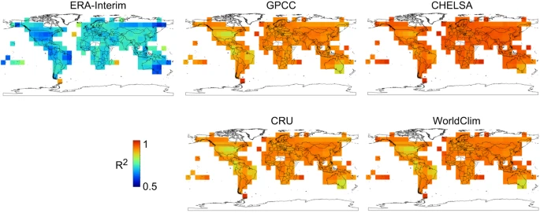

Models have been calculated for each station separately, including a minimum of 16 surrounding stations in a 2° search radius. This illustrates how well modelled precipitation corresponds to measured stations at the scale <=2°. The figure shows the mean R<sup>2</sup> value for 2° grid cells. The upper row additionally illustrates different steps of the CHELSA algorithm, with ERA-Interim<sup>17</sup> performing worse than GPCC<sup>50</sup>, and CHELSA showing the highest fit after including orographic effects.

[Full size image](https://www.nature.com/articles/sdata2017122/figures/2)

### Validation using independent precipitation station data

[Full size table](https://www.nature.com/articles/sdata2017122/tables/3)

[Full size table](https://www.nature.com/articles/sdata2017122/tables/4)

Precipitation validation data:

1. 1

   FAO—data: 2,316 stations
2. 2

   Mexico—data: 2,950 stations
3. 3

   Austria—Ehyd data: 877 stations
4. 4

   South Africa—SAEON data: 14 stations
5. 5

   Scandinavia—Nordklim data: 11 stations
6. 6

   China—CMA data: 241 stations

### FAO data validation results

The FAO data obtained from the Agromet Group of the Food and Agriculture Organization of the United Nations (FAO) is a collection of 2,316 stations with a good representation in many typically data-sparse regions, but many stations only have a short measuring period. The data is global and duplicates in the GHCN data report have been removed.

### Mexico data validation results

The Mexico data consist of 2,950 stations with a dense spatial distribution, but with only a short measuring period for many stations.

### Austria Ehyd data validation results

The Ehyd data from the Federal Ministry of Agriculture, Forestry, Environment and Water Management of Austria comprises of a dense net of 877 precipitation stations in Austria.

### Skandinavia—Nordklim data

The Nordklim data 1.0 includes observations of twelve climate variables from more than 119 stations in the Nordic region including precipitation and air temperature, in a time span of over 100 years. The data are provided by NORDKLIM/NORDMET on behalf of the National meteorological services in Denmark (DMI), Finland (FMI), Iceland (VI), Norway (DNMI) and Sweden (SMHI). We screened these stations for duplicates in the GHCN dataset and remained with a set of 11 independent stations which we used for the validation.

### South Africa—SAEON data validation results

One of the main purposes of CHELSA is the better representation of precipitation gradients at small spatial scales. The SAEON precipitation stations are located in the Jonkershoek valley in South Africa with a strong elevational gradient, from the entrance to the valley to the watershed at the top of the valley. They additionally have a very high interannual variability and have not been included in any global precipitation product. Although the timespan of the dataset is too low to validate the climatological performance, the dataset can be used to track the performance of models in a very complex terrain and a strong seasonality.

For all stations of the SAEON network, CHELSA predicts the temporal variation and the actual precipitation values best compared to the ERA-Interim, CRU and CHIRPS<sup>1</sup> reanalysis products (Fig. 3). All reanalysis products predict the temporal variation in precipitation well, but they differ in the respective errors. All of them underestimate the extremes of precipitation in the region covered by the SAEON data.

**Figure 3: Temporal precision of the CHELSA reanalysis which forms the basis for the climatologies in a small region of South Africa.**

[figure not shown]

Precipitation anomalies are shown as deviations from the mean precipitation in the respective time period. Grey=station data, red=CHELSA, green=ERA-Interim<sup>17</sup>, blue=CRU<sup>9</sup>, orange=CHIRPS<sup>1</sup>.

[Full size image](https://www.nature.com/articles/sdata2017122/figures/3)

### Large-scale spatial comparison of precipitation patterns

To compare our precipitation data with those of other products, we first compared the spatial patterns of precipitation with those of the Tropical Rainfall Measuring Mission (TRMM)<sup>2,3</sup> combined multisatellite product TRMM/TMPA (3B43)<sup>53</sup>, CRU<sup>9</sup>, WorldClim<sup>8</sup>, CHPclim<sup>52</sup>, GPCC<sup>50</sup>, and ERA-Interim<sup>17</sup>. Figure 4 shows the bias of all mentioned products with the CRU dataset. We used the CRU dataset as a comparison, as it is not included in the other datasets, and therefore the most independent. TRMM/TMPA (3B43), WorldClim, GPCC are all using similar stations, and ERA-Interim is known to exhibit large biases in precipitation. All products, with the exception of ERA-Interim show similar amounts and patterns of biases when compared to CRU data. The bias of CHELSA is lower than that of GPCC and ERA-Interim, the two datasets which have been used in the correction algorithm. The large scale comparison however, only serves as a guideline for the deviation in the above mentioned products in general and cannot be seen as independent validation. For regions in which all models exhibit large biases, we would urge caution in the use of a single precipitation product and would suggest the use of multiple models from various sources.

**Figure 4: Bias ratio comparison of annual precipitation sums for six different climatologies with the CRU<sup>9</sup> climatology at the global scale.**

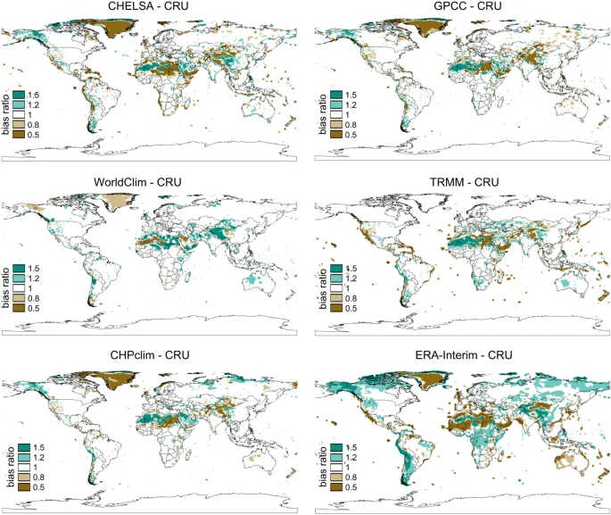

All models have a substantial dry bias over Greenland when compared to CRU (TRMM/TMPA (3B43)<sup>53</sup> does not include Greenland). Large differences in bias ratios can be observed in the Atacama, where CHELSA, and GPCC<sup>50</sup> are drier than CRU, and WorldClim<sup>8</sup>, CHPclim<sup>52</sup>, TRMM/TMPA (3B43), and ERA-Interim<sup>17</sup> are wetter. Also on the Himalaya plateau large differences are visible, with CHELSA, GPCC, and TRMM (3B43) being drier, and WorldClim and ERA-Interim being wetter.

[Full size image](https://www.nature.com/articles/sdata2017122/figures/4)

### Small-scale comparison of precipitation patterns

**Figure 5: Comparison of precipitation patterns in the complex terrain of Bhutan (country boundaries in black) between TRMM/TMPA (3B43)<sup>53</sup>, WorldClim<sup>8</sup>, CHELSA, the statistical downscaling approach of Böhner<sup>31</sup>, the topography from GMTED2010<sup>29</sup>, and the cloud cover climatology from Wilson & Jetz<sup>54</sup>.**

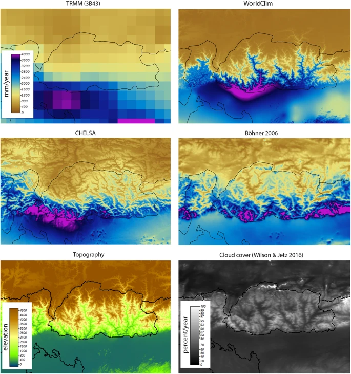

In this region, most precipitation falls during the SW-monsoon in the northern summer, when wet air masses from the SW are lifted at the south face of the Himalayas and dry until reaching the Tibetan high plateau. While the mesoscale patterns are in congruence between models, there are clear differences at the microscale. WorldClim<sup>8</sup> predicts wet valleys and dry mountain faces, whereas CHELSA and Böhner<sup>31</sup> predict dry valleys and wet windward exposed mountain faces due to the inclusion of orographic predictors. CHELSA and Böhner<sup>31</sup> are also in closer congruence with the observed distribution of cloud in the area, which shows lower cloud cover in the isolated mountain valleys compared to the wind exposed mountain faces in the south.

[Full size image](https://www.nature.com/articles/sdata2017122/figures/5)

### Validation of temperature using independent meteorological stations

We compared CHELSA temperature data to that of MODIS (MOD11C3)<sup>56</sup> and several independent station datasets. Other high resolution products for temperature such as WorldClim do not have the same validation period as CHELSA. A comparison is therefore problematic due to the increase of global temperatures in the last decades<sup>57</sup>. PRISM<sup>11</sup> is geographically restricted to the United States and therefore also not available for global comparisons. As climate station data not directly used by the CHELSA algorithm for temperature, a comparison with station data is possible. We used a set of four different station networks with different temporal and spatial extent for the validation.

### Temperature validation data:

1. 1

   FAO—data: 400 stations
2. 2

   Mexico—data: 2,915 stations
3. 3

   GHCN—data: 6,093 stations
4. 4

   Scandinavia—Nordklim data: 32 stations

[Full size table](https://www.nature.com/articles/sdata2017122/tables/5)

[Full size table](https://www.nature.com/articles/sdata2017122/tables/6)

### CHELSA—MODIS comparison

**Figure 6: Temporal comparison of the CHELSA algorithm with GHCN Version 3 (temperature)<sup>14</sup>, and MODIS (MOD11C3)<sup>56</sup>.**

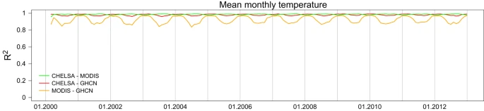

Coefficients of determination give the global correlation between products for a specific month. CHELSA temperatures show significantly higher correlations with GHCN (Wilcoxon Test: W=23,254, *P*<0.001). Correlations between CHELSA and MODIS for temperature (mean R<sup>2</sup>=0.99).

[Full size image](https://www.nature.com/articles/sdata2017122/figures/6)

The high spatial correlation between CHELSA and MODIS (MOD11C3)<sup>56</sup> shows that CHELSA is able to predict spatial patterns of temperature distributions well, and additionally accurately predicts the observed values of temperature on a small scale.

### Application example: Performance for species distribution modelling

As we are generally interested in the use of CHELSA climatologies for ecological studies we compare the performance of CHELSA in a species distribution modelling (SDM) approach<sup>59,60</sup> to the most commonly used climate dataset for this purpose: WorldClim<sup>8</sup>. We calculated SDMs for 67 species from Switzerland. We used species from Switzerland as this allows a comparison of performances in areas where climate station density is high in CHELSA and WorldClim, and tests whether the performance improvement of CHELSA is also found in areas with detailed climate data. We modelled species using a generalized linear model with mean annual precipitation and mean annual temperature as predictors. We randomly sampled six times as many pseudo-absence points as presence points and used an inverse weighting approach on the resulting presences and absences. We evaluated the models in a 10-fold cross-validation using the area under the receiver operating characteristic curve (AUC), Kappa statistics<sup>61</sup> and true skill statistic<sup>62</sup> (TSS). AUC and Kappa are traditional test measures between predicted and observed data and usually ranges from 0.5 (AUC) or 0 (Kappa), indicating random fit, to 1, indicating perfect fit. TSS assesses model specificity and sensitivity and ranges from zero (both the specificity and the sensitivity of the model are zero) to 1 (both specificity and sensitivity are 1). Additionally, we calculated the adjusted D<sup>2</sup> value which represents the percentage deviance explained by (goodness-of-fit of) the model. Model performance for all 67 species was then compared using a paired *t*-test of all species distribution models.

The result shows an improvement of the models when using CHELSA over WorldClim data (Fig. 7). All measures show a higher performance of the CHELSA data, although the difference in mean is not significant for the TSS. This shows that even in areas with comparably high station density and good climatic information the CHELSA algorithm improves the spatial prediction of climatic variables and subsequently the modelled distribution of species (Fig. 8).

**Figure 7: Comparison of the performance of 67 species distribution models using generalized linear models with WorldClim (blue) and CHELSA (red) precipitation and temperatures in Switzerland as predictors.**

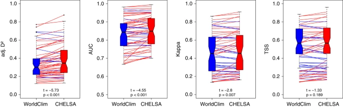

Models are compared using paired *t* tests on model performance statistics (adjusted D<sup>2</sup>, the area under the receiver operation statistics curve (AUC), Kappa statistics, and true skill statistics (TSS)). All performance statistics indicate a higher mean performance of CHELSA over WorldClim<sup>8</sup>, with only the TSS statistics not being significant. Red lines indicate models in which SDMs based on CHELSA performed better then SDMs based on WorldClim, blue indicates the opposite relationship. T-values are given for the paired *t*-test comparing WorldClim with CHELSA.

[Full size image](https://www.nature.com/articles/sdata2017122/figures/7)

**Figure 8: Comparison of species distribution models based and climate data from WorldClim<sup>8</sup> and CHELSA of *Astragalus monspessulanus* for Switzerland.**

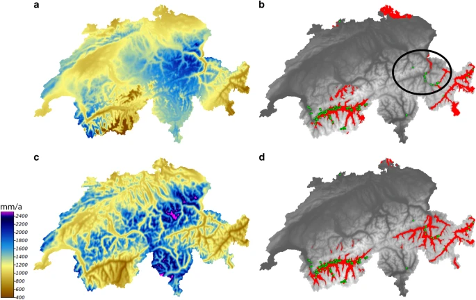

Models were calculated using generalized linear models with mean annual precipitation from WorldClim (**a**) and CHELSA (**c**), as well as the mean annual temperature. The distributions based on WorldClim (**b**) and CHELSA (**d**) represent a binary distribution (red) with a threshold of the maximum kappa (WorldClim: threshold=0.675, AUC=0.89, D<sup>2</sup>=0.36, Kappa=0.60, TSS=0.66, CHELSA: threshold=0.7155, AUC=0.91, D<sup>2</sup>=0.47, Kappa=0.66, TSS=0.76). Occurrences are marked in green. The circle indicates the area of the dry Rhine valley in eastern Switzerland in which WorldClim overestimates precipitation and therefore does not predict the range of the species correctly in that region (compare with **d**).

[Full size image](https://www.nature.com/articles/sdata2017122/figures/8)

### Validation results—Conclusions

The validation results in general show that including orographic effects can improve existing climatologies and reanalysis to a degree that the derived analysis (here the SDMs) show increasing accuracies. While CHELSA is an improvement over existing very high-resolution climatologies, it still exhibits errors which we quantified in several ways. The validation of main correction step in the algorithm that includes the orographic wind effects and boundary layer shows that the precipitation at the stations is better captured after the correction than before the downscaling to 30 arc sec resolution. The improvement varies by region and month with the majority of months showing an improvement. Most importantly, the better prediction with regard to SDMs in which precipitation and temperature data are used already indicates that CHELSA might be a substantial improvement over existing products which are currently being employed for such purposes.

## Usage Notes

All CHELSA products are in a geographic coordinate system referenced to the WGS 84 horizontal datum, with the horizontal coordinates expressed in decimal degrees. The CHELSA layer extents (minimum and maximum latitude and longitude) are a result of the coordinate system inherited from the 1-arc-second GMTED2010 data which itself inherited the grid extent from the 1-arc-second SRTM data.

Note that because of the pixel center referencing of the input GMTED2010 data the full extent of each CHELSA grid as defined by the outside edges of the pixels differs from an integer value of latitude or longitude by 0.000138888888 degree (or 1/2 arc-second). Users of products based on the legacy GTOPO30 product should note that the coordinate referencing of CHELSA (and GMTED2010) and GTOPO30 are not the same. In GTOPO30, the integer lines of latitude and longitude fall directly on the edges of a 30-arc-second pixel. Thus, when overlaying CHELSA with products based on GTOPO30 a slight shift of 1/2 arc-second will be observed between the edges of corresponding 30-arc-second pixels.

The dataset is in GEOtiff format. GEOtiff can be viewed using standard GIS software such as:

SAGA GIS—(free) http://www.saga-gis.org/

ArcGIS—https://www.arcgis.com/

QGIS—(free) http://www.qgis.org

DIVA—GIS—(free) http://www.diva-gis.org/

GRASS—GIS—(free) https://grass.osgeo.org/

Grid extent:

Resolution (decimal degrees): 0.0083333333

West extent (minimum X-coordinate, longitude): −180.0001388888

South extent (minimum Y-coordinate, latitude): −90.0001388888

East extent (maximum X-coordinate, longitude): 179.9998611111

North extent (maximum Y-coordinate, latitude): 83.9998611111

Rows: 20,800

Columns: 43,200

The data are feely available under the Creative Commons Licence: CC 0.

## Additional Information

**How to cite this article:** Karger, D. N. *et al.* Climatologies at high resolution for the earth’s land surface areas. *Sci. Data* 4:170122 doi: 10.1038/sdata.2017.122 (2017).

**Publisher’s note:** Springer Nature remains neutral with regard to jurisdictional claims in published maps and institutional affiliations.

## References

### References

1. 1

   Funk, C. et al. The climate hazards infrared precipitation with stations—a new environmental record for monitoring extremes. *Sci. Data* **2**, 150066 (2015).

   [Article](https://doi.org/10.1038%2Fsdata.2015.66) Google Scholar
2. 2

   Biasutti, M., Yuter, S. E., Burleyson, C. D. & Sobel, A. H. Very high resolution rainfall patterns measured by TRMM precipitation radar: seasonal and diurnal cycles. *Clim. Dyn* **39**, 239–258 (2011).

   [Article](https://doi.org/10.1007%2Fs00382-011-1146-6) Google Scholar
3. 3

   Huffman, G. J. et al. The TRMM Multisatellite Precipitation Analysis (TMPA): Quasi-Global, Multiyear, Combined-Sensor Precipitation Estimates at Fine Scales. *J. Hydrometeorol.* **8**, 38–55 (2007).

   [ADS](http://adsabs.harvard.edu/cgi-bin/nph-data_query?link_type=ABSTRACT&bibcode=2007JHyMe...8...38H) [Article](https://doi.org/10.1175%2FJHM560.1) Google Scholar
4. 4

   Maraun, D. et al. Precipitation downscaling under climate change: Recent developments to bridge the gap between dynamical models and the end user. *Rev. Geophys.* **48**, RG3003 (2010).

   [ADS](http://adsabs.harvard.edu/cgi-bin/nph-data_query?link_type=ABSTRACT&bibcode=2010RvGeo..48.3003M) [Article](https://doi.org/10.1029%2F2009RG000314) Google Scholar
5. 5

   Wood, A. W., Leung, L. R., Sridhar, V. & Lettenmaier, D. P. Hydrologic Implications of Dynamical and Statistical Approaches to Downscaling Climate Model Outputs. *Clim. Change* **62**, 189–216 (2004).

   [Article](https://doi.org/10.1023%2FB%3ACLIM.0000013685.99609.9e) Google Scholar
6. 6

   Wilby, R. L. et al. Statistical downscaling of general circulation model output: A comparison of methods. *Water Resour. Res.* **34**, 2995–3008 (1998).

   [ADS](http://adsabs.harvard.edu/cgi-bin/nph-data_query?link_type=ABSTRACT&bibcode=1998WRR....34.2995W) [Article](https://doi.org/10.1029%2F98WR02577) Google Scholar
7. 7

   Schmidli, J., Frei, C. & Vidale, P. L. Downscaling from GCM precipitation: a benchmark for dynamical and statistical downscaling methods. *Int. J. Climatol.* **26**, 679–689 (2006).

   [Article](https://doi.org/10.1002%2Fjoc.1287) Google Scholar
8. 8

   Hijmans, R. J., Cameron, S. E., Parra, J. L., Jones, P. G. & Jarvis, A. Very high resolution interpolated climate surfaces for global land areas. *Int. J. Climatol.* **25**, 1965–1978 (2005).

   [Article](https://doi.org/10.1002%2Fjoc.1276) Google Scholar
9. 9

   Harris, I., Jones, P. d., Osborn, T. J. & Lister, D. H. Updated high-resolution grids of monthly climatic observations—the CRU TS3.10 Dataset. *Int. J. Climatol.* **34**, 623–642 (2014).

   [Article](https://doi.org/10.1002%2Fjoc.3711) Google Scholar
10. 10

    Schneider, U. et al. GPCC’s new land surface precipitation climatology based on quality-controlled in situ data and its role in quantifying the global water cycle. *Theor. Appl. Climatol.* **115**, 15–40 (2013).

    [ADS](http://adsabs.harvard.edu/cgi-bin/nph-data_query?link_type=ABSTRACT&bibcode=2014ThApC.115...15S) [Article](https://doi.org/10.1007%2Fs00704-013-0860-x) Google Scholar
11. 11

    Daly, C., Taylor, G. H. & Gibson, W. P. The PRISM approach to mapping precipitation and temperature. *in Proc., 10th AMS Conf. on Applied Climatology* 20–23 (1997).
12. 12

    Deblauwe, V. et al. Remotely sensed temperature and precipitation data improve species distribution modelling in the tropics. *Glob. Ecol. Biogeogr* **25**, 443–454 (2016).

    [Article](https://doi.org/10.1111%2Fgeb.12426) Google Scholar
13. 13

    Soria-Auza, R. W. et al. Impact of the quality of climate models for modelling species occurrences in countries with poor climatic documentation: a case study from Bolivia. *Ecol. Model.* **221**, 1221–1229 (2010).

    [Article](https://doi.org/10.1016%2Fj.ecolmodel.2010.01.004) Google Scholar
14. 14

    Lawrimore, J. H. et al. An overview of the Global Historical Climatology Network monthly mean temperature data set, version 3. *J. Geophys. Res. Atmospheres* **116**, 1–18 (2011).

    [Article](https://doi.org/10.1029%2F2011JD016187) Google Scholar
15. 15

    Peterson, T. C. & Vose, R. S. An overview of the Global Historical Climatology Network temperature database. *Bull. Am. Meteorol. Soc* **78**, 2837–2849 (1997).

    [Article](https://doi.org/10.1175%2F1520-0477%281997%29078%3C2837%3AAOOTGH%3E2.0.CO%3B2) Google Scholar
16. 16

    Kalnay, E. et al. The NCEP/NCAR 40-Year Reanalysis Project. *Bull. Am. Meteorol. Soc* **77**, 437–471 (1996).

    [Article](https://doi.org/10.1175%2F1520-0477%281996%29077%3C0437%3ATNYRP%3E2.0.CO%3B2) [Google Scholar](http://scholar.google.com/scholar_lookup?&title=The%20NCEP%2FNCAR%2040-Year%20Reanalysis%20Project&journal=Bull.%20Am.%20Meteorol.%20Soc&volume=77&pages=437-471&publication_year=1996&author=Kalnay%2CE)
17. 17

    Dee, D. P. et al. The ERA-Interim reanalysis: configuration and performance of the data assimilation system. *Q. J. R. Meteorol. Soc* **137**, 553–597 (2011).

    [ADS](http://adsabs.harvard.edu/cgi-bin/nph-data_query?link_type=ABSTRACT&bibcode=2011QJRMS.137..553D) [Article](https://doi.org/10.1002%2Fqj.828) Google Scholar
18. 18

    Wilby, R. L. & Wigley, T. M. L. Downscaling general circulation model output: a review of methods and limitations. *Prog. Phys. Geogr.* **21**, 530–548 (1997).

    [Article](https://doi.org/10.1177%2F030913339702100403) Google Scholar
19. 19

    Böhner, J., Antonic, O., Böhner, J. & Antonic, O. in *Geomorphometry: Concepts, Software, Applications* (eds Hengl T. & Reuter H. I. ) 195–226 (Elsevier Science, 2009).

    Google Scholar
20. 20

    Gerlitz, L., Conrad, O. & Böhner, J. Large-scale atmospheric forcing and topographic modification of precipitation rates over High Asia—a neural-network-based approach. *Earth Syst Dynam* **6**, 61–81 (2015).

    [ADS](http://adsabs.harvard.edu/cgi-bin/nph-data_query?link_type=ABSTRACT&bibcode=2015ESD.....6...61G) [Article](https://doi.org/10.5194%2Fesd-6-61-2015) Google Scholar
21. 21

    Berrisford, P. et al. The ERA-interim archive. *ERA Rep. Ser* 1–16 (2009).
22. 22

    Berrisford, P. et al. Atmospheric conservation properties in ERA-Interim. *Q. J. R. Meteorol. Soc* **137**, 1381–1399 (2011).

    [ADS](http://adsabs.harvard.edu/cgi-bin/nph-data_query?link_type=ABSTRACT&bibcode=2011QJRMS.137.1381B) [Article](https://doi.org/10.1002%2Fqj.864) Google Scholar
23. 23

    Gao, L. et al. Statistical Downscaling of ERA-Interim Forecast Precipitation Data in Complex Terrain Using LASSO Algorithm, Statistical Downscaling of ERA-Interim Forecast Precipitation Data in Complex Terrain Using LASSO Algorithm. *Adv. Meteorol. Adv. Meteorol.* e472741 (2014).
24. 24

    Bao, X. & Zhang, F. Evaluation of NCEP-CFSR, NCEP-NCAR, ERA-Interim, and ERA-40 Reanalysis Datasets against Independent Sounding Observations over the Tibetan Plateau. *J. Clim* **26**, 206–214 (2012).

    [ADS](http://adsabs.harvard.edu/cgi-bin/nph-data_query?link_type=ABSTRACT&bibcode=2013JCli...26..206B) [Article](https://doi.org/10.1175%2FJCLI-D-12-00056.1) Google Scholar
25. 25

    Betts, A. K., Köhler, M. & Zhang, Y. Comparison of river basin hydrometeorology in ERA-Interim and ERA-40 reanalyses with observations. *J. Geophys. Res. Atmospheres* **114**, D02101 (2009).

    [ADS](http://adsabs.harvard.edu/cgi-bin/nph-data_query?link_type=ABSTRACT&bibcode=2009JGRD..114.2101B) [Article](https://doi.org/10.1029%2F2008JD010761) Google Scholar
26. 26

    Hansen, J., Sato, M. & Ruedy, R. Radiative forcing and climate response. *J. Geophys. Res. Atmospheres* **102**, 6831–6864 (1997).

    [CAS](https://www.nature.com/articles/cas-redirect/1%3ACAS%3A528%3ADyaK2sXivVyrtb8%253D) [ADS](http://adsabs.harvard.edu/cgi-bin/nph-data_query?link_type=ABSTRACT&bibcode=1997JGR...102.6831H) [Article](https://doi.org/10.1029%2F96JD03436) Google Scholar
27. 27

    Rolland, C. Spatial and Seasonal Variations of Air Temperature Lapse Rates in Alpine Regions. *J. Clim* **16**, 1032–1046 (2003).

    [ADS](http://adsabs.harvard.edu/cgi-bin/nph-data_query?link_type=ABSTRACT&bibcode=2003JCli...16.1032R) [Article](https://doi.org/10.1175%2F1520-0442%282003%29016%3C1032%3ASASVOA%3E2.0.CO%3B2) Google Scholar
28. 28

    Minder, J. R., Mote, P. W. & Lundquist, J. D. Surface temperature lapse rates over complex terrain: Lessons from the Cascade Mountains. *J. Geophys. Res. Atmospheres* **115**, D14122 (2010).

    [ADS](http://adsabs.harvard.edu/cgi-bin/nph-data_query?link_type=ABSTRACT&bibcode=2010JGRD..11514122M) [Article](https://doi.org/10.1029%2F2009JD013493) Google Scholar
29. 29

    Danielson, J. J. & Gesch, D. B. *Global multi-resolution terrain elevation data 2010 (GMTED2010)*. (US Geological Survey, 2011).

    [Google Scholar](http://scholar.google.com/scholar_lookup?&title=Global%20multi-resolution%20terrain%20elevation%20data%202010%20%28GMTED2010%29&publication_year=2011&author=Danielson%2CJJ&author=Gesch%2CDB)
30. 30

    Hunter, R. D. & Meentemeyer, R. K. Climatologically Aided Mapping of Daily Precipitation and Temperature. *J. Appl. Meteorol.* **44**, 1501–1510 (2005).

    [ADS](http://adsabs.harvard.edu/cgi-bin/nph-data_query?link_type=ABSTRACT&bibcode=2005JApMe..44.1501H) [Article](https://doi.org/10.1175%2FJAM2295.1) Google Scholar
31. 31

    Böhner, J. General climatic controls and topoclimatic variations in Central and High Asia. *Boreas* **35**, 279–295 (2006).

    [Article](https://doi.org/10.1080%2F03009480500456073) Google Scholar
32. 32

    Spreen, W. C. A determination of the effect of topography upon precipitation. *Eos Trans. Am. Geophys. Union* **28**, 285–290 (1947).

    [Article](https://doi.org/10.1029%2FTR028i002p00285) Google Scholar
33. 33

    Gao, X., Xu, Y., Zhao, Z., Pal, J. S. & Giorgi, F. On the role of resolution and topography in the simulation of East Asia precipitation. *Theor. Appl. Climatol.* **86**, 173–185 (2006).

    [ADS](http://adsabs.harvard.edu/cgi-bin/nph-data_query?link_type=ABSTRACT&bibcode=2006ThApC..86..173G) [Article](https://doi.org/10.1007%2Fs00704-005-0214-4) Google Scholar
34. 34

    Basist, A., Bell, G. D. & Meentemeyer, V. Statistical Relationships between Topography and Precipitation Patterns. *J. Clim* **7**, 1305–1315 (1994).

    [ADS](http://adsabs.harvard.edu/cgi-bin/nph-data_query?link_type=ABSTRACT&bibcode=1994JCli....7.1305B) [Article](https://doi.org/10.1175%2F1520-0442%281994%29007%3C1305%3ASRBTAP%3E2.0.CO%3B2) Google Scholar
35. 35

    Daly, C., Neilson, R. P. & Phillips, D. L. A Statistical-Topographic Model for Mapping Climatological Precipitation over Mountainous Terrain. *J. Appl. Meteorol.* **33**, 140–158 (1994).

    [ADS](http://adsabs.harvard.edu/cgi-bin/nph-data_query?link_type=ABSTRACT&bibcode=1994JApMe..33..140D) [Article](https://doi.org/10.1175%2F1520-0450%281994%29033%3C0140%3AASTMFM%3E2.0.CO%3B2) Google Scholar
36. 36

    Sevruk, B. Regional Dependency of Precipitation-Altitude Relationship in the Swiss Alpsin *Climatic Change at High Elevation Sites* (eds Diaz, H. F., Beniston, M. & Bradley, R. S. ) 123–137 (Springer Netherlands, 1997).

    Google Scholar
37. 37

    Körner, C. The use of ‘altitude’ in ecological research. *Trends Ecol. Evol.* **22**, 569–574 (2007).

    [Article](https://doi.org/10.1016%2Fj.tree.2007.09.006) Google Scholar
38. 38

    Rotunno, R. & Houze, R. A. Lessons on orographic precipitation from the Mesoscale Alpine Programme. *Q. J. R. Meteorol. Soc* **133**, 811–830 (2007).

    [ADS](http://adsabs.harvard.edu/cgi-bin/nph-data_query?link_type=ABSTRACT&bibcode=2007QJRMS.133..811R) [Article](https://doi.org/10.1002%2Fqj.67) Google Scholar
39. 39

    Weischet, W. & Endlicher, W. *Einführung in die allgemeine Klimatologie* (2008).
40. 40

    Roe, G. H. Orographic Precipitation. *Annu. Rev. Earth Planet. Sci.* **33**, 645–671 (2005).

    [CAS](https://www.nature.com/articles/cas-redirect/1%3ACAS%3A528%3ADC%252BD2MXlsV2htr4%253D) [ADS](http://adsabs.harvard.edu/cgi-bin/nph-data_query?link_type=ABSTRACT&bibcode=2005AREPS..33..645R) [Article](https://doi.org/10.1146%2Fannurev.earth.33.092203.122541) [Google Scholar](http://scholar.google.com/scholar_lookup?&title=Orographic%20Precipitation&journal=Annu.%20Rev.%20Earth%20Planet.%20Sci.&volume=33&pages=645-671&publication_year=2005&author=Roe%2CGH)
41. 41

    Colle, B. A. Sensitivity of Orographic Precipitation to Changing Ambient Conditions and Terrain Geometries: An Idealized Modeling Perspective. *J. Atmospheric Sci* **61**, 588–606 (2004).

    [ADS](http://adsabs.harvard.edu/cgi-bin/nph-data_query?link_type=ABSTRACT&bibcode=2004JAtS...61..588C) [Article](https://doi.org/10.1175%2F1520-0469%282004%29061%3C0588%3ASOOPTC%3E2.0.CO%3B2) Google Scholar
42. 42

    Sinclair, M. R. A Diagnostic Model for Estimating Orographic Precipitation. *J. Appl. Meteorol.* **33**, 1163–1175 (1994).

    [ADS](http://adsabs.harvard.edu/cgi-bin/nph-data_query?link_type=ABSTRACT&bibcode=1994JApMe..33.1163S) [Article](https://doi.org/10.1175%2F1520-0450%281994%29033%3C1163%3AADMFEO%3E2.0.CO%3B2) Google Scholar
43. 43

    Smith, R. B. & Barstad, I. A Linear Theory of Orographic Precipitation. *J. Atmospheric Sci* **61**, 1377–1391 (2004).

    [ADS](http://adsabs.harvard.edu/cgi-bin/nph-data_query?link_type=ABSTRACT&bibcode=2004JAtS...61.1377S) [Article](https://doi.org/10.1175%2F1520-0469%282004%29061%3C1377%3AALTOOP%3E2.0.CO%3B2) Google Scholar
44. 44

    Oke, T. R. . *Boundary layer climates*. Routledge, (2002).

    [Google Scholar](http://scholar.google.com/scholar_lookup?&title=Boundary%20layer%20climates&publication_year=2002&author=Oke%2CTR)
45. 45

    Stull, R. B. *An introduction to boundary layer meteorology* **13** (Springer Science & Business Media, 2012).

    [Google Scholar](http://scholar.google.com/scholar_lookup?&title=An%20introduction%20to%20boundary%20layer%20meteorology&publication_year=2012&author=Stull%2CRB)
46. 46

    Kållberg, P. *Forecast drift in ERA-Interim* (European Centre for Medium Range Weather Forecasts, 2011).

    [Google Scholar](http://scholar.google.com/scholar_lookup?&title=Forecast%20drift%20in%20ERA-Interim&publication_year=2011&author=K%C3%A5llberg%2CP)
47. 47

    Lafon, T., Dadson, S., Buys, G. & Prudhomme, C. Bias correction of daily precipitation simulated by a regional climate model: a comparison of methods. *Int. J. Climatol.* **33**, 1367–1381 (2013).

    [Article](https://doi.org/10.1002%2Fjoc.3518) Google Scholar
48. 48

    Arnell, N. W., Hudson, D. A. & Jones, R. G. Climate change scenarios from a regional climate model: Estimating change in runoff in southern Africa. *J. Geophys. Res. Atmospheres* **108**, 4519 (2003).

    [ADS](http://adsabs.harvard.edu/cgi-bin/nph-data_query?link_type=ABSTRACT&bibcode=2003JGRD..108.4519A) [Article](https://doi.org/10.1029%2F2002JD002782) Google Scholar
49. 49

    Molteni, F. A. *‘historical’ approach to the rescaling of ERA-Interim precipitation, internal technical note* (European Centre for Medium Range Weather Forecasts, 2013).

    Google Scholar
50. 50

    Meyer-Christoffer, A. et al. GPCC Climatology Version 2015 at 0.25°: Monthly Land-Surface Precipitation Climatology for Every Month and the Total Year from Rain-Gauges built on GTS-based and Historic Data. *Global Precipitation Climatology Centre at Deutscher Wetterdienst* doi: 10.5676/DWD_GPCC/CLIM_M_V2015_025 (2015).
51. 51

    Xu, T. & Hutchinson, M. F. New Developments and Applications in the ANUCLIM Spatial Climatic and Bioclimatic Modelling Package. *Env. Model Softw* **40**, 267–279 (2013).

    [Article](https://doi.org/10.1016%2Fj.envsoft.2012.10.003) Google Scholar
52. 52

    Funk, C. et al. A global satellite-assisted precipitation climatology. *Earth Syst Sci Data* **7**, 275–287 (2015).

    [ADS](http://adsabs.harvard.edu/cgi-bin/nph-data_query?link_type=ABSTRACT&bibcode=2015ESSD....7..275F) [Article](https://doi.org/10.5194%2Fessd-7-275-2015) [Google Scholar](http://scholar.google.com/scholar_lookup?&title=A%20global%20satellite-assisted%20precipitation%20climatology&journal=Earth%20Syst%20Sci%20Data&volume=7&pages=275-287&publication_year=2015&author=Funk%2CC)
53. 53

    Goddard Space Flight Center Distributed Active Archive Center (GSFC DAAC). *TRMM/TMPA 3B43 TRMM and Other Sources Monthly Rainfall Product V7* (2011).
54. 54

    Wilson, A. M. & Jetz, W. Remotely Sensed High-Resolution Global Cloud Dynamics for Predicting Ecosystem and Biodiversity Distributions. *PLOS Biol* **14**, e1002415 (2016).

    [Article](https://doi.org/10.1371%2Fjournal.pbio.1002415) Google Scholar
55. 55

    Pruppacher, H. R., Klett, J. D. & Wang, P. K. Microphysics of Clouds and Precipitation. *Aerosol Science and Technology* **28**, 381–382 (1998).

    [ADS](http://adsabs.harvard.edu/cgi-bin/nph-data_query?link_type=ABSTRACT&bibcode=1998AerST..28..381P) [Article](https://doi.org/10.1080%2F02786829808965531) Google Scholar
56. 56

    NASA LP DAAC. *MODIS/Terra Land Surface Temperature and Emissivity Monthly L3 Global 0.05Deg CMG*. NASA EOSDIS Land Processes DAAC, USGS Earth Resources Observation and Science (EROS) Center, (2015).
57. 57

    Stocker, T. F. et al. IPCC, 2013: climate change 2013: the physical science basis. Contribution of working group I to the fifth assessment report of the intergovernmental panel on climate change (2013).
58. 58

    Wan, Z., Zhang, Y., Zhang, Q. & Li, Z.-L. Quality assessment and validation of the MODIS global land surface temperature. *Int. J. Remote Sens.* **25**, 261–274 (2004).

    [ADS](http://adsabs.harvard.edu/cgi-bin/nph-data_query?link_type=ABSTRACT&bibcode=2004IJRS...25..261W) [Article](https://doi.org/10.1080%2F0143116031000116417) Google Scholar
59. 59

    Guisan, A. & Zimmermann, N. E. Predictive habitat distribution models in ecology. *Ecol. Model.* **135**, 147–186 (2000).

    [Article](https://doi.org/10.1016%2FS0304-3800%2800%2900354-9) Google Scholar
60. 60

    Guisan, A. & Thuiller, W. Predicting species distribution: offering more than simple habitat models. *Ecol. Lett.* **8**, 993–1009 (2005).

    [Article](https://doi.org/10.1111%2Fj.1461-0248.2005.00792.x) Google Scholar
61. 61

    Warren, D. L., Glor, R. E. & Turelli, M. Environmental Niche Equivalency Versus Conservatism: Quantitative Approaches to Niche Evolution. *Evolution* **62**, 2868–2883 (2008).

    [Article](https://doi.org/10.1111%2Fj.1558-5646.2008.00482.x) Google Scholar
62. 62

    Allouche, O., Tsoar, A. & Kadmon, R. Assessing the accuracy of species distribution models: prevalence, kappa and the true skill statistic (TSS). *J. Appl. Ecol.* **43**, 1223–1232 (2006).

    [Article](https://doi.org/10.1111%2Fj.1365-2664.2006.01214.x) Google Scholar

### Data Citations

1. 1

   Karger, D. N. *Dryad Digital Repository* https://doi.org/10.5061/dryad.kd1d4 (2017)

[Download references](https://www.nature.com/articles/sdata2017122-references.ris)

## Acknowledgements

M.K. & D.N.K. would like to acknowledge funding from the Swiss National Funds (SNF 147630, SNF 146906). We thank Sergio Maffioletti for implementing the CHELSA algorithm on the science cloud grid computing facility of the University of Zurich. We further thank Stefan Eggenberg and InfoFlora for access to 67 plant species for test modelling.

## Author information

### Affiliations

1. Department of Systematic and Evolutionary Botany, University of Zurich, Zollikerstrasse 107, Zurich, 8008, Switzerland

   Dirk Nikolaus Karger, H. Peter Linder & Michael Kessler
2. Swiss Federal Research Institute WSL, Zürcherstr 111, Birmensdorf, 8903, Switzerland

   Dirk Nikolaus Karger & Niklaus E. Zimmermann
3. Institute of Geography, University of Hamburg, Bundesstrasse 55, Hamburg, 20146, Germany

   Olaf Conrad, Jürgen Böhner & Tobias Kawohl
4. Biodiversity, Macroecology & Conservation Biogeography Group, University of Göttingen, Göttingen, 37077, Germany

   Holger Kreft & Rodrigo Wilber Soria-Auza
5. Asociación Armonía, Av. Lomas de Arena # 400, Zona Palmasola, 10260, Santa Cruz de la Sierra, Bolivia

   Rodrigo Wilber Soria-Auza

### Contributions

M.K. initiated the project. D.N.K., O.K., and T.K. developed the algorithms in close communication with J.B. R.W.S. compiled the GHCN data and removed the errors. M.K., H.K., P.L., and N.Z. provided the funding for the project. D.N.K. wrote the first draft of the manuscript and all authors contributed significantly to the revisions.

### Corresponding author

Correspondence to [Dirk Nikolaus Karger](https://www.nature.com/articles/sdata2017122/email/correspondent/c1/new).

## Ethics declarations

### Competing interests

The authors declare no competing financial interests.

## ISA-Tab metadata

### [ISA-Tab metadata](https://static-content.springer.com/esm/art%3A10.1038%2Fsdata.2017.122/MediaObjects/41597_2017_BFsdata2017122_MOESM227_ESM.zip)

## Rights and permissions

**Open Access** This article is licensed under a Creative Commons Attribution 4.0 International License, which permits use, sharing, adaptation, distribution and reproduction in any medium or format, as long as you give appropriate credit to the original author(s) and the source, provide a link to the Creative Commons license, and indicate if changes were made. The images or other third party material in this article are included in the article’s Creative Commons license, unless indicated otherwise in a credit line to the material. If material is not included in the article’s Creative Commons license and your intended use is not permitted by statutory regulation or exceeds the permitted use, you will need to obtain permission directly from the copyright holder. To view a copy of this license, visit http://creativecommons.org/licenses/by/4.0/ The Creative Commons Public Domain Dedication waiver http://creativecommons.org/publicdomain/zero/1.0/ applies to the metadata files made available in this article.

Reprints and Permissions

## About this article

### Cite this article

Karger, D., Conrad, O., Böhner, J. *et al.* Climatologies at high resolution for the earth’s land surface areas. *Sci Data* **4,** 170122 (2017). https://doi.org/10.1038/sdata.2017.122

[Download citation](https://www.nature.com/articles/sdata2017122.ris)

- Received: 11 October 2016
- Accepted: 21 July 2017
- Published: 05 September 2017
- DOI: https://doi.org/10.1038/sdata.2017.122

### Share this article

Anyone you share the following link with will be able to read this content:

Provided by the Springer Nature SharedIt content-sharing initiative

### Subjects

- [Atmospheric science](https://www.nature.com/subjects/atmospheric-science)
- [Biogeography](https://www.nature.com/subjects/biogeography)
- [Hydrology](https://www.nature.com/subjects/hydrology)

## Further reading

  *Agriculture, Ecosystems & Environment* (2021)

- - Yehui Zhong
  - , Zhenshan Xue
  - [[…]](https://www.nature.com/articles/sdata2017122)
  - & Guodong Wang

  *Ecological Indicators* (2021)

- - Robert R. Junker
  - , Florian Griessenberger
  - & Wolfgang Trutschnig

  *Computational Statistics & Data Analysis* (2021)

- - Damaris Zurell
  - , Janet Franklin
  - [[…]](https://www.nature.com/articles/sdata2017122)
  - & Cory Merow

  *Ecography* (2020)

- - Allison Perrigo
  - , Carina Hoorn
  - & Alexandre Antonelli

  *Journal of Biogeography* (2020)

[Download PDF](https://www.nature.com/articles/sdata2017122.pdf)

# Associated Content

*Scientific Data* | Data Descriptor